# Risk Factor Analysis

## Outcome Variable

**Outcome Variable:** whz

## Predictor Variables

**Intervention Variable:** impfloor

**Adjustment Set:**

unadjusted

## Stratifying Variables

The analysis was stratified on these variable(s):

- agecat
- studyid
- country

## Data Summary

| agecat | studyid | country | impfloor | n_cell | n |
| --- | --- | --- | --- | --- | --- |
| Birth | CMC-V-BCS-2002 | INDIA | 1 | 68 | 68 |
| Birth | CMC-V-BCS-2002 | INDIA | 0 | 0 | 68 |
| Birth | CONTENT | PERU | 1 | 2 | 2 |
| Birth | CONTENT | PERU | 0 | 0 | 2 |
| Birth | GMS-Nepal | NEPAL | 1 | 97 | 503 |
| Birth | GMS-Nepal | NEPAL | 0 | 406 | 503 |
| Birth | IRC | INDIA | 1 | 253 | 253 |
| Birth | IRC | INDIA | 0 | 0 | 253 |
| Birth | MAL-ED | BANGLADESH | 1 | 185 | 201 |
| Birth | MAL-ED | BANGLADESH | 0 | 16 | 201 |
| Birth | MAL-ED | BRAZIL | 1 | 55 | 57 |
| Birth | MAL-ED | BRAZIL | 0 | 2 | 57 |
| Birth | MAL-ED | INDIA | 1 | 33 | 39 |
| Birth | MAL-ED | INDIA | 0 | 6 | 39 |
| Birth | MAL-ED | NEPAL | 1 | 8 | 24 |
| Birth | MAL-ED | NEPAL | 0 | 16 | 24 |
| Birth | MAL-ED | PERU | 1 | 37 | 210 |
| Birth | MAL-ED | PERU | 0 | 173 | 210 |
| Birth | MAL-ED | SOUTH AFRICA | 1 | 86 | 95 |
| Birth | MAL-ED | SOUTH AFRICA | 0 | 9 | 95 |
| Birth | MAL-ED | TANZANIA, UNITED REPUBLIC OF | 1 | 5 | 111 |
| Birth | MAL-ED | TANZANIA, UNITED REPUBLIC OF | 0 | 106 | 111 |
| Birth | NIH-Birth | BANGLADESH | 1 | 505 | 572 |
| Birth | NIH-Birth | BANGLADESH | 0 | 67 | 572 |
| Birth | NIH-Crypto | BANGLADESH | 1 | 542 | 707 |
| Birth | NIH-Crypto | BANGLADESH | 0 | 165 | 707 |
| Birth | PROVIDE | BANGLADESH | 1 | 485 | 532 |
| Birth | PROVIDE | BANGLADESH | 0 | 47 | 532 |
| 6 months | CMC-V-BCS-2002 | INDIA | 1 | 257 | 257 |
| 6 months | CMC-V-BCS-2002 | INDIA | 0 | 0 | 257 |

[output cut: 54 more lines]

The following strata were considered:

- agecat: 24 months, studyid: CMC-V-BCS-2002, country: INDIA
- agecat: 24 months, studyid: CONTENT, country: PERU
- agecat: 24 months, studyid: GMS-Nepal, country: NEPAL
- agecat: 24 months, studyid: IRC, country: INDIA
- agecat: 24 months, studyid: MAL-ED, country: BANGLADESH
- agecat: 24 months, studyid: MAL-ED, country: BRAZIL
- agecat: 24 months, studyid: MAL-ED, country: INDIA
- agecat: 24 months, studyid: MAL-ED, country: NEPAL
- agecat: 24 months, studyid: MAL-ED, country: PERU
- agecat: 24 months, studyid: MAL-ED, country: SOUTH AFRICA
- agecat: 24 months, studyid: MAL-ED, country: TANZANIA, UNITED REPUBLIC OF
- agecat: 24 months, studyid: NIH-Birth, country: BANGLADESH
- agecat: 24 months, studyid: NIH-Crypto, country: BANGLADESH
- agecat: 24 months, studyid: PROVIDE, country: BANGLADESH
- agecat: 6 months, studyid: CMC-V-BCS-2002, country: INDIA
- agecat: 6 months, studyid: CONTENT, country: PERU
- agecat: 6 months, studyid: GMS-Nepal, country: NEPAL
- agecat: 6 months, studyid: IRC, country: INDIA
- agecat: 6 months, studyid: MAL-ED, country: BANGLADESH
- agecat: 6 months, studyid: MAL-ED, country: BRAZIL
- agecat: 6 months, studyid: MAL-ED, country: INDIA
- agecat: 6 months, studyid: MAL-ED, country: NEPAL
- agecat: 6 months, studyid: MAL-ED, country: PERU
- agecat: 6 months, studyid: MAL-ED, country: SOUTH AFRICA
- agecat: 6 months, studyid: MAL-ED, country: TANZANIA, UNITED REPUBLIC OF
- agecat: 6 months, studyid: NIH-Birth, country: BANGLADESH
- agecat: 6 months, studyid: NIH-Crypto, country: BANGLADESH
- agecat: 6 months, studyid: PROVIDE, country: BANGLADESH
- agecat: Birth, studyid: CMC-V-BCS-2002, country: INDIA
- agecat: Birth, studyid: CONTENT, country: PERU
- agecat: Birth, studyid: GMS-Nepal, country: NEPAL
- agecat: Birth, studyid: IRC, country: INDIA
- agecat: Birth, studyid: MAL-ED, country: BANGLADESH
- agecat: Birth, studyid: MAL-ED, country: BRAZIL
- agecat: Birth, studyid: MAL-ED, country: INDIA
- agecat: Birth, studyid: MAL-ED, country: NEPAL
- agecat: Birth, studyid: MAL-ED, country: PERU
- agecat: Birth, studyid: MAL-ED, country: SOUTH AFRICA
- agecat: Birth, studyid: MAL-ED, country: TANZANIA, UNITED REPUBLIC OF
- agecat: Birth, studyid: NIH-Birth, country: BANGLADESH
- agecat: Birth, studyid: NIH-Crypto, country: BANGLADESH
- agecat: Birth, studyid: PROVIDE, country: BANGLADESH

### Dropped Strata

- agecat: Birth, studyid: CMC-V-BCS-2002, country: INDIA
- agecat: Birth, studyid: CONTENT, country: PERU
- agecat: Birth, studyid: IRC, country: INDIA
- agecat: Birth, studyid: MAL-ED, country: BRAZIL
- agecat: 6 months, studyid: CMC-V-BCS-2002, country: INDIA
- agecat: 6 months, studyid: IRC, country: INDIA
- agecat: 6 months, studyid: MAL-ED, country: BRAZIL
- agecat: 24 months, studyid: CMC-V-BCS-2002, country: INDIA
- agecat: 24 months, studyid: IRC, country: INDIA
- agecat: 24 months, studyid: MAL-ED, country: BRAZIL

## Methods Detail

We’re interested in the causal parameters $E[Y_a]$ for all values of $a \in \mathcal{A}$. These parameters represent the mean outcome if, possibly contrary to fact, we intervened to set all units to have $A=a$. Under the randomization and positivity assumptions, these are identified by the statistical parameters $\psi_a=E_W[E_{Y|A,W}(Y|A=a,W)]$. In addition, we’re interested in the mean of $Y$, $E[Y]$ under no intervention (the observed mean). We will estimate these parameters by using SuperLearner to fit the relevant likelihood factors – $E_{Y|A,W}(Y|A=a,W)$ and $p(A=a|W)$, and then updating our likelihood fit using a joint TMLE.

For unadjusted analyses ($W=\{\}$), initial likelihoods were estimated using Lrnr_glm to estimate the simple $E(Y|A)$ and Lrnr_mean to estimate $p(A)$. For adjusted analyses, a small library containing Lrnr_glmnet, Lrnr_xgboost, and Lrnr_mean was used.

Having estimated these parameters, we will then use the delta method to estimate relative risks and attributable risks relative to a prespecified baseline level of $A$.

# Results Detail

## Results Plots

[figure not shown]

[figure not shown]

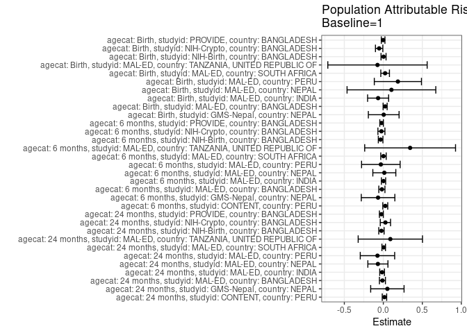

## Results Table

### Parameter: TSM

| agecat | studyid | country | intervention_level | baseline_level | estimate | ci_lower | ci_upper |
| --- | --- | --- | --- | --- | --- | --- | --- |
| Birth | GMS-Nepal | NEPAL | 1 | NA | -1.0909278 | -1.3096699 | -0.8721857 |
| Birth | GMS-Nepal | NEPAL | 0 | NA | -1.0849015 | -1.1930925 | -0.9767104 |
| Birth | MAL-ED | BANGLADESH | 1 | NA | -0.9958919 | -1.1557706 | -0.8360132 |
| Birth | MAL-ED | BANGLADESH | 0 | NA | -0.7062500 | -0.9540327 | -0.4584673 |
| Birth | MAL-ED | INDIA | 1 | NA | -0.8772727 | -1.1935310 | -0.5610144 |
| Birth | MAL-ED | INDIA | 0 | NA | -1.3116667 | -2.0623390 | -0.5609943 |
| Birth | MAL-ED | NEPAL | 1 | NA | -0.9125000 | -1.6413488 | -0.1836512 |
| Birth | MAL-ED | NEPAL | 0 | NA | -0.7568750 | -1.1980753 | -0.3156747 |
| Birth | MAL-ED | PERU | 1 | NA | -0.2335135 | -0.5745355 | 0.1075085 |
| Birth | MAL-ED | PERU | 0 | NA | -0.0068786 | -0.1420489 | 0.1282917 |
| Birth | MAL-ED | SOUTH AFRICA | 1 | NA | -0.1959302 | -0.4617510 | 0.0698905 |
| Birth | MAL-ED | SOUTH AFRICA | 0 | NA | 0.0466667 | -0.4532880 | 0.5466213 |
| Birth | MAL-ED | TANZANIA, UNITED REPUBLIC OF | 1 | NA | 0.8440000 | 0.2094403 | 1.4785597 |
| Birth | MAL-ED | TANZANIA, UNITED REPUBLIC OF | 0 | NA | 0.7655660 | 0.5608207 | 0.9703114 |
| Birth | NIH-Birth | BANGLADESH | 1 | NA | -1.3476139 | -1.4495511 | -1.2456766 |
| Birth | NIH-Birth | BANGLADESH | 0 | NA | -1.3240299 | -1.5788672 | -1.0691925 |
| Birth | NIH-Crypto | BANGLADESH | 1 | NA | -1.1904705 | -1.2856303 | -1.0953107 |
| Birth | NIH-Crypto | BANGLADESH | 0 | NA | -1.4204848 | -1.5959106 | -1.2450591 |
| Birth | PROVIDE | BANGLADESH | 1 | NA | -1.2956701 | -1.3763022 | -1.2150380 |
| Birth | PROVIDE | BANGLADESH | 0 | NA | -1.3272340 | -1.5795198 | -1.0749483 |
| 6 months | CONTENT | PERU | 1 | NA | 1.0396119 | 0.9182294 | 1.1609944 |
| 6 months | CONTENT | PERU | 0 | NA | 1.4207143 | 0.9906630 | 1.8507656 |
| 6 months | GMS-Nepal | NEPAL | 1 | NA | -0.5598291 | -0.7980139 | -0.3216442 |
| 6 months | GMS-Nepal | NEPAL | 0 | NA | -0.6418916 | -0.7493416 | -0.5344417 |
| 6 months | MAL-ED | BANGLADESH | 1 | NA | -0.1146833 | -0.2486487 | 0.0192822 |
| 6 months | MAL-ED | BANGLADESH | 0 | NA | -0.3502632 | -0.8176916 | 0.1171653 |
| 6 months | MAL-ED | INDIA | 1 | NA | -0.7126780 | -0.8453182 | -0.5800379 |
| 6 months | MAL-ED | INDIA | 0 | NA | -0.6752222 | -1.0830695 | -0.2673750 |
| 6 months | MAL-ED | NEPAL | 1 | NA | 0.1153722 | -0.0797204 | 0.3104648 |
| 6 months | MAL-ED | NEPAL | 0 | NA | 0.1385847 | -0.0448681 | 0.3220374 |
| 6 months | MAL-ED | PERU | 1 | NA | 1.0828879 | 0.7984978 | 1.3672781 |
| 6 months | MAL-ED | PERU | 0 | NA | 1.0425432 | 0.9071202 | 1.1779662 |
| 6 months | MAL-ED | SOUTH AFRICA | 1 | NA | 0.5386390 | 0.3752068 | 0.7020712 |
| 6 months | MAL-ED | SOUTH AFRICA | 0 | NA | 0.5610000 | 0.1590909 | 0.9629091 |
| 6 months | MAL-ED | TANZANIA, UNITED REPUBLIC OF | 1 | NA | 0.1921429 | -0.4103635 | 0.7946492 |
| 6 months | MAL-ED | TANZANIA, UNITED REPUBLIC OF | 0 | NA | 0.5563925 | 0.4213479 | 0.6914371 |
| 6 months | NIH-Birth | BANGLADESH | 1 | NA | -0.4098864 | -0.5067896 | -0.3129833 |
| 6 months | NIH-Birth | BANGLADESH | 0 | NA | -0.7313793 | -0.9725391 | -0.4902196 |
| 6 months | NIH-Crypto | BANGLADESH | 1 | NA | 0.0543017 | -0.0374388 | 0.1460422 |
| 6 months | NIH-Crypto | BANGLADESH | 0 | NA | -0.0442697 | -0.1984281 | 0.1098888 |
| 6 months | PROVIDE | BANGLADESH | 1 | NA | -0.1767534 | -0.2630945 | -0.0904123 |
| 6 months | PROVIDE | BANGLADESH | 0 | NA | -0.4695652 | -0.7448374 | -0.1942930 |
| 24 months | CONTENT | PERU | 1 | NA | 0.5757792 | 0.4357748 | 0.7157837 |
| 24 months | CONTENT | PERU | 0 | NA | 0.8130000 | 0.3923400 | 1.2336600 |
| 24 months | GMS-Nepal | NEPAL | 1 | NA | -1.2508565 | -1.4887477 | -1.0129653 |
| 24 months | GMS-Nepal | NEPAL | 0 | NA | -1.1866999 | -1.3035422 | -1.0698576 |
| 24 months | MAL-ED | BANGLADESH | 1 | NA | -0.8077949 | -0.9341289 | -0.6814609 |
| 24 months | MAL-ED | BANGLADESH | 0 | NA | -0.9511765 | -1.4088437 | -0.4935092 |
| 24 months | MAL-ED | INDIA | 1 | NA | -0.9359434 | -1.0554667 | -0.8164201 |
| 24 months | MAL-ED | INDIA | 0 | NA | -1.1736667 | -1.6019136 | -0.7454198 |
| 24 months | MAL-ED | NEPAL | 1 | NA | -0.2774490 | -0.4507195 | -0.1041785 |
| 24 months | MAL-ED | NEPAL | 0 | NA | -0.4026829 | -0.5550729 | -0.2502930 |
| 24 months | MAL-ED | PERU | 1 | NA | 0.1863605 | -0.0693406 | 0.4420617 |
| 24 months | MAL-ED | PERU | 0 | NA | 0.0869682 | -0.0530887 | 0.2270251 |
| 24 months | MAL-ED | SOUTH AFRICA | 1 | NA | 0.4042462 | 0.2751613 | 0.5333311 |
| 24 months | MAL-ED | SOUTH AFRICA | 0 | NA | 0.4675000 | 0.1966855 | 0.7383145 |
| 24 months | MAL-ED | TANZANIA, UNITED REPUBLIC OF | 1 | NA | -0.0420833 | -0.4589904 | 0.3748237 |
| 24 months | MAL-ED | TANZANIA, UNITED REPUBLIC OF | 0 | NA | 0.0531333 | -0.0777419 | 0.1840085 |
| 24 months | NIH-Birth | BANGLADESH | 1 | NA | -0.8863719 | -0.9916999 | -0.7810439 |
| 24 months | NIH-Birth | BANGLADESH | 0 | NA | -1.0934000 | -1.3612968 | -0.8255032 |
| 24 months | NIH-Crypto | BANGLADESH | 1 | NA | -0.6369653 | -0.7526951 | -0.5212356 |
| 24 months | NIH-Crypto | BANGLADESH | 0 | NA | -0.5555357 | -0.7197739 | -0.3912975 |
| 24 months | PROVIDE | BANGLADESH | 1 | NA | -0.8677486 | -0.9536587 | -0.7818385 |
| 24 months | PROVIDE | BANGLADESH | 0 | NA | -1.1839130 | -1.4730698 | -0.8947563 |

### Parameter: E(Y)

| agecat | studyid | country | intervention_level | baseline_level | estimate | ci_lower | ci_upper |
| --- | --- | --- | --- | --- | --- | --- | --- |
| Birth | GMS-Nepal | NEPAL | NA | NA | -1.0860636 | -1.1830454 | -0.9890818 |
| Birth | MAL-ED | BANGLADESH | NA | NA | -0.9728358 | -1.1217009 | -0.8239707 |
| Birth | MAL-ED | INDIA | NA | NA | -0.9441026 | -1.2397919 | -0.6484132 |
| Birth | MAL-ED | NEPAL | NA | NA | -0.8087500 | -1.1914221 | -0.4260779 |
| Birth | MAL-ED | PERU | NA | NA | -0.0468095 | -0.1738806 | 0.0802616 |
| Birth | MAL-ED | SOUTH AFRICA | NA | NA | -0.1729474 | -0.4186222 | 0.0727275 |
| Birth | MAL-ED | TANZANIA, UNITED REPUBLIC OF | NA | NA | 0.7690991 | 0.5714748 | 0.9667234 |
| Birth | NIH-Birth | BANGLADESH | NA | NA | -1.3448514 | -1.4396716 | -1.2500312 |
| Birth | NIH-Crypto | BANGLADESH | NA | NA | -1.2441513 | -1.3281130 | -1.1601897 |
| Birth | PROVIDE | BANGLADESH | NA | NA | -1.2984586 | -1.3752758 | -1.2216415 |
| 6 months | CONTENT | PERU | NA | NA | 1.0644279 | 0.9468682 | 1.1819876 |
| 6 months | GMS-Nepal | NEPAL | NA | NA | -0.6273772 | -0.7253868 | -0.5293676 |
| 6 months | MAL-ED | BANGLADESH | NA | NA | -0.1333333 | -0.2623761 | -0.0042906 |
| 6 months | MAL-ED | INDIA | NA | NA | -0.7102872 | -0.8371659 | -0.5834085 |
| 6 months | MAL-ED | NEPAL | NA | NA | 0.1281441 | -0.0056126 | 0.2619008 |
| 6 months | MAL-ED | PERU | NA | NA | 1.0512099 | 0.9285617 | 1.1738581 |
| 6 months | MAL-ED | SOUTH AFRICA | NA | NA | 0.5404351 | 0.3867005 | 0.6941696 |
| 6 months | MAL-ED | TANZANIA, UNITED REPUBLIC OF | NA | NA | 0.5355782 | 0.4032519 | 0.6679046 |
| 6 months | NIH-Birth | BANGLADESH | NA | NA | -0.4447399 | -0.5354039 | -0.3540758 |
| 6 months | NIH-Crypto | BANGLADESH | NA | NA | 0.0297622 | -0.0491685 | 0.1086930 |
| 6 months | PROVIDE | BANGLADESH | NA | NA | -0.1990907 | -0.2817968 | -0.1163845 |
| 24 months | CONTENT | PERU | NA | NA | 0.5902439 | 0.4560143 | 0.7244735 |
| 24 months | GMS-Nepal | NEPAL | NA | NA | -1.1990840 | -1.3039914 | -1.0941766 |
| 24 months | MAL-ED | BANGLADESH | NA | NA | -0.8192925 | -0.9412667 | -0.6973182 |
| 24 months | MAL-ED | INDIA | NA | NA | -0.9516520 | -1.0670654 | -0.8362385 |
| 24 months | MAL-ED | NEPAL | NA | NA | -0.3471493 | -0.4618867 | -0.2324120 |
| 24 months | MAL-ED | PERU | NA | NA | 0.1111982 | -0.0118399 | 0.2342362 |
| 24 months | MAL-ED | SOUTH AFRICA | NA | NA | 0.4090301 | 0.2879441 | 0.5301161 |
| 24 months | MAL-ED | TANZANIA, UNITED REPUBLIC OF | NA | NA | 0.0477437 | -0.0779935 | 0.1734809 |
| 24 months | NIH-Birth | BANGLADESH | NA | NA | -0.9106710 | -1.0090143 | -0.8123277 |
| 24 months | NIH-Crypto | BANGLADESH | NA | NA | -0.6103502 | -0.7050157 | -0.5156847 |
| 24 months | PROVIDE | BANGLADESH | NA | NA | -0.8928670 | -0.9755153 | -0.8102187 |

### Parameter: ATE

| agecat | studyid | country | intervention_level | baseline_level | estimate | ci_lower | ci_upper |
| --- | --- | --- | --- | --- | --- | --- | --- |
| Birth | GMS-Nepal | NEPAL | 1 | 1 | 0.0000000 | 0.0000000 | 0.0000000 |
| Birth | GMS-Nepal | NEPAL | 0 | 1 | 0.0060264 | -0.2380093 | 0.2500620 |
| Birth | MAL-ED | BANGLADESH | 1 | 1 | 0.0000000 | 0.0000000 | 0.0000000 |
| Birth | MAL-ED | BANGLADESH | 0 | 1 | 0.2896419 | -0.0052437 | 0.5845274 |
| Birth | MAL-ED | INDIA | 1 | 1 | 0.0000000 | 0.0000000 | 0.0000000 |
| Birth | MAL-ED | INDIA | 0 | 1 | -0.4343939 | -1.2489664 | 0.3801785 |
| Birth | MAL-ED | NEPAL | 1 | 1 | 0.0000000 | 0.0000000 | 0.0000000 |
| Birth | MAL-ED | NEPAL | 0 | 1 | 0.1556250 | -0.6963599 | 1.0076099 |
| Birth | MAL-ED | PERU | 1 | 1 | 0.0000000 | 0.0000000 | 0.0000000 |
| Birth | MAL-ED | PERU | 0 | 1 | 0.2266349 | -0.1401989 | 0.5934687 |
| Birth | MAL-ED | SOUTH AFRICA | 1 | 1 | 0.0000000 | 0.0000000 | 0.0000000 |
| Birth | MAL-ED | SOUTH AFRICA | 0 | 1 | 0.2425969 | -0.3236321 | 0.8088259 |
| Birth | MAL-ED | TANZANIA, UNITED REPUBLIC OF | 1 | 1 | 0.0000000 | 0.0000000 | 0.0000000 |
| Birth | MAL-ED | TANZANIA, UNITED REPUBLIC OF | 0 | 1 | -0.0784340 | -0.7452073 | 0.5883394 |
| Birth | NIH-Birth | BANGLADESH | 1 | 1 | 0.0000000 | 0.0000000 | 0.0000000 |
| Birth | NIH-Birth | BANGLADESH | 0 | 1 | 0.0235840 | -0.2508851 | 0.2980531 |
| Birth | NIH-Crypto | BANGLADESH | 1 | 1 | 0.0000000 | 0.0000000 | 0.0000000 |
| Birth | NIH-Crypto | BANGLADESH | 0 | 1 | -0.2300144 | -0.4295879 | -0.0304409 |
| Birth | PROVIDE | BANGLADESH | 1 | 1 | 0.0000000 | 0.0000000 | 0.0000000 |
| Birth | PROVIDE | BANGLADESH | 0 | 1 | -0.0315639 | -0.2964217 | 0.2332939 |
| 6 months | CONTENT | PERU | 1 | 1 | 0.0000000 | 0.0000000 | 0.0000000 |
| 6 months | CONTENT | PERU | 0 | 1 | 0.3811023 | -0.0657509 | 0.8279556 |
| 6 months | GMS-Nepal | NEPAL | 1 | 1 | 0.0000000 | 0.0000000 | 0.0000000 |
| 6 months | GMS-Nepal | NEPAL | 0 | 1 | -0.0820626 | -0.3433622 | 0.1792371 |
| 6 months | MAL-ED | BANGLADESH | 1 | 1 | 0.0000000 | 0.0000000 | 0.0000000 |
| 6 months | MAL-ED | BANGLADESH | 0 | 1 | -0.2355799 | -0.7218269 | 0.2506671 |
| 6 months | MAL-ED | INDIA | 1 | 1 | 0.0000000 | 0.0000000 | 0.0000000 |
| 6 months | MAL-ED | INDIA | 0 | 1 | 0.0374558 | -0.3914181 | 0.4663297 |
| 6 months | MAL-ED | NEPAL | 1 | 1 | 0.0000000 | 0.0000000 | 0.0000000 |
| 6 months | MAL-ED | NEPAL | 0 | 1 | 0.0232125 | -0.2445860 | 0.2910110 |
| 6 months | MAL-ED | PERU | 1 | 1 | 0.0000000 | 0.0000000 | 0.0000000 |
| 6 months | MAL-ED | PERU | 0 | 1 | -0.0403447 | -0.3553322 | 0.2746428 |
| 6 months | MAL-ED | SOUTH AFRICA | 1 | 1 | 0.0000000 | 0.0000000 | 0.0000000 |
| 6 months | MAL-ED | SOUTH AFRICA | 0 | 1 | 0.0223610 | -0.4115065 | 0.4562285 |
| 6 months | MAL-ED | TANZANIA, UNITED REPUBLIC OF | 1 | 1 | 0.0000000 | 0.0000000 | 0.0000000 |
| 6 months | MAL-ED | TANZANIA, UNITED REPUBLIC OF | 0 | 1 | 0.3642496 | -0.2532056 | 0.9817048 |
| 6 months | NIH-Birth | BANGLADESH | 1 | 1 | 0.0000000 | 0.0000000 | 0.0000000 |
| 6 months | NIH-Birth | BANGLADESH | 0 | 1 | -0.3214929 | -0.5813933 | -0.0615924 |
| 6 months | NIH-Crypto | BANGLADESH | 1 | 1 | 0.0000000 | 0.0000000 | 0.0000000 |
| 6 months | NIH-Crypto | BANGLADESH | 0 | 1 | -0.0985713 | -0.2779624 | 0.0808197 |
| 6 months | PROVIDE | BANGLADESH | 1 | 1 | 0.0000000 | 0.0000000 | 0.0000000 |
| 6 months | PROVIDE | BANGLADESH | 0 | 1 | -0.2928118 | -0.5813071 | -0.0043164 |
| 24 months | CONTENT | PERU | 1 | 1 | 0.0000000 | 0.0000000 | 0.0000000 |
| 24 months | CONTENT | PERU | 0 | 1 | 0.2372208 | -0.2061256 | 0.6805672 |
| 24 months | GMS-Nepal | NEPAL | 1 | 1 | 0.0000000 | 0.0000000 | 0.0000000 |
| 24 months | GMS-Nepal | NEPAL | 0 | 1 | 0.0641566 | -0.2008799 | 0.3291931 |
| 24 months | MAL-ED | BANGLADESH | 1 | 1 | 0.0000000 | 0.0000000 | 0.0000000 |
| 24 months | MAL-ED | BANGLADESH | 0 | 1 | -0.1433816 | -0.6181653 | 0.3314021 |
| 24 months | MAL-ED | INDIA | 1 | 1 | 0.0000000 | 0.0000000 | 0.0000000 |
| 24 months | MAL-ED | INDIA | 0 | 1 | -0.2377233 | -0.6823368 | 0.2068903 |
| 24 months | MAL-ED | NEPAL | 1 | 1 | 0.0000000 | 0.0000000 | 0.0000000 |
| 24 months | MAL-ED | NEPAL | 0 | 1 | -0.1252339 | -0.3559835 | 0.1055156 |
| 24 months | MAL-ED | PERU | 1 | 1 | 0.0000000 | 0.0000000 | 0.0000000 |
| 24 months | MAL-ED | PERU | 0 | 1 | -0.0993923 | -0.3909383 | 0.1921536 |
| 24 months | MAL-ED | SOUTH AFRICA | 1 | 1 | 0.0000000 | 0.0000000 | 0.0000000 |
| 24 months | MAL-ED | SOUTH AFRICA | 0 | 1 | 0.0632538 | -0.2367519 | 0.3632594 |
| 24 months | MAL-ED | TANZANIA, UNITED REPUBLIC OF | 1 | 1 | 0.0000000 | 0.0000000 | 0.0000000 |
| 24 months | MAL-ED | TANZANIA, UNITED REPUBLIC OF | 0 | 1 | 0.0952167 | -0.3417499 | 0.5321833 |
| 24 months | NIH-Birth | BANGLADESH | 1 | 1 | 0.0000000 | 0.0000000 | 0.0000000 |
| 24 months | NIH-Birth | BANGLADESH | 0 | 1 | -0.2070281 | -0.4948869 | 0.0808307 |
| 24 months | NIH-Crypto | BANGLADESH | 1 | 1 | 0.0000000 | 0.0000000 | 0.0000000 |
| 24 months | NIH-Crypto | BANGLADESH | 0 | 1 | 0.0814296 | -0.1194872 | 0.2823464 |
| 24 months | PROVIDE | BANGLADESH | 1 | 1 | 0.0000000 | 0.0000000 | 0.0000000 |
| 24 months | PROVIDE | BANGLADESH | 0 | 1 | -0.3161645 | -0.6178135 | -0.0145154 |

### Parameter: PAR

| agecat | studyid | country | intervention_level | baseline_level | estimate | ci_lower | ci_upper |
| --- | --- | --- | --- | --- | --- | --- | --- |
| Birth | GMS-Nepal | NEPAL | 1 | NA | 0.0048642 | -0.1921110 | 0.2018394 |
| Birth | MAL-ED | BANGLADESH | 1 | NA | 0.0230561 | -0.0028101 | 0.0489223 |
| Birth | MAL-ED | INDIA | 1 | NA | -0.0668298 | -0.2016929 | 0.0680332 |
| Birth | MAL-ED | NEPAL | 1 | NA | 0.1037500 | -0.4650307 | 0.6725307 |
| Birth | MAL-ED | PERU | 1 | NA | 0.1867040 | -0.1157238 | 0.4891318 |
| Birth | MAL-ED | SOUTH AFRICA | 1 | NA | 0.0229829 | -0.0325492 | 0.0785150 |
| Birth | MAL-ED | TANZANIA, UNITED REPUBLIC OF | 1 | NA | -0.0749009 | -0.7116467 | 0.5618449 |
| Birth | NIH-Birth | BANGLADESH | 1 | NA | 0.0027625 | -0.0293929 | 0.0349178 |
| Birth | NIH-Crypto | BANGLADESH | 1 | NA | -0.0536809 | -0.1008071 | -0.0065546 |
| Birth | PROVIDE | BANGLADESH | 1 | NA | -0.0027885 | -0.0262000 | 0.0206229 |
| 6 months | CONTENT | PERU | 1 | NA | 0.0248160 | -0.0068917 | 0.0565236 |
| 6 months | GMS-Nepal | NEPAL | 1 | NA | -0.0675481 | -0.2826514 | 0.1475552 |
| 6 months | MAL-ED | BANGLADESH | 1 | NA | -0.0186501 | -0.0579802 | 0.0206800 |
| 6 months | MAL-ED | INDIA | 1 | NA | 0.0023908 | -0.0250093 | 0.0297908 |
| 6 months | MAL-ED | NEPAL | 1 | NA | 0.0127719 | -0.1345833 | 0.1601272 |
| 6 months | MAL-ED | PERU | 1 | NA | -0.0316781 | -0.2790095 | 0.2156534 |
| 6 months | MAL-ED | SOUTH AFRICA | 1 | NA | 0.0017961 | -0.0330609 | 0.0366531 |
| 6 months | MAL-ED | TANZANIA, UNITED REPUBLIC OF | 1 | NA | 0.3434354 | -0.2388333 | 0.9257041 |
| 6 months | NIH-Birth | BANGLADESH | 1 | NA | -0.0348534 | -0.0642773 | -0.0054296 |
| 6 months | NIH-Crypto | BANGLADESH | 1 | NA | -0.0245394 | -0.0693083 | 0.0202294 |
| 6 months | PROVIDE | BANGLADESH | 1 | NA | -0.0223372 | -0.0452043 | 0.0005298 |
| 24 months | CONTENT | PERU | 1 | NA | 0.0144647 | -0.0139384 | 0.0428678 |
| 24 months | GMS-Nepal | NEPAL | 1 | NA | 0.0517725 | -0.1621197 | 0.2656646 |
| 24 months | MAL-ED | BANGLADESH | 1 | NA | -0.0114976 | -0.0499307 | 0.0269355 |
| 24 months | MAL-ED | INDIA | 1 | NA | -0.0157086 | -0.0460804 | 0.0146633 |
| 24 months | MAL-ED | NEPAL | 1 | NA | -0.0697003 | -0.1983895 | 0.0589888 |
| 24 months | MAL-ED | PERU | 1 | NA | -0.0751624 | -0.2957142 | 0.1453895 |
| 24 months | MAL-ED | SOUTH AFRICA | 1 | NA | 0.0047839 | -0.0180053 | 0.0275731 |
| 24 months | MAL-ED | TANZANIA, UNITED REPUBLIC OF | 1 | NA | 0.0898270 | -0.3224163 | 0.5020704 |
| 24 months | NIH-Birth | BANGLADESH | 1 | NA | -0.0242991 | -0.0586741 | 0.0100760 |
| 24 months | NIH-Crypto | BANGLADESH | 1 | NA | 0.0266151 | -0.0391373 | 0.0923676 |
| 24 months | PROVIDE | BANGLADESH | 1 | NA | -0.0251184 | -0.0500768 | -0.0001601 |